# All Interactions Are Wrong (?)

part 2: family vs link function

toffa et al. x psicostat

## Problems with interactions?

- GLM *family* ensures the data distribution is well approximated, and the error term is correctly specified (so you avoid inflating coefficients precision)
- …but it’s the *link function* that ensures that the *linear predictor* $X$ is appropriately mapped on the response scale $Y$, and **determines how differences in $X$ translate to differences in $Y$, which is critical for interactions!**
- Each GLM *family* typical has an optimal choice, aka the *canonical link function*

## a “time” (rt) scenario

```r
set.seed(10)
library(ggplot2)
library(effects)

N = 5e4
A = rbinom(N,1,.5)
B = rbinom(N,1,.5)

b0 = 1
b1 = 1
b2 = 0.5
```

```r
X = b0 + b1*A + b2*B

rt = rgamma(N, shape = 5, scale = 20*exp(X))
```

- `A` e `B` sono fattori a 2 livelli
- `shape = 5` determina una *skewness* = `2/sqrt(shape)` = `0.89` in ciascuna condizione
- `rgamma` stabilisce che la distribuzione degli `rt` sarà una *Gamma*
- `exp(X)` determina che la *link function* è `"log"`

## observed distributions

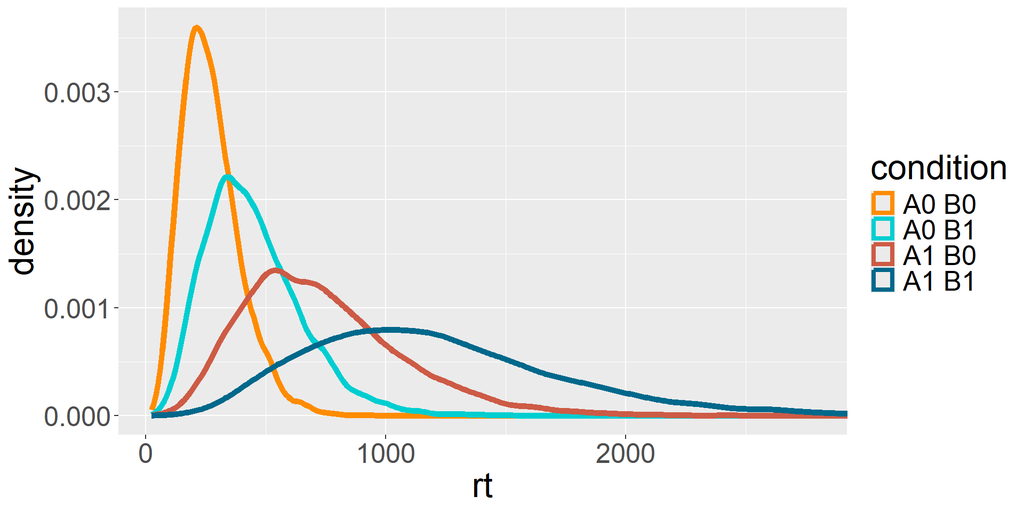

```r
df = data.frame(rt,A,B)
condition = paste(paste0("A",A),paste0("B",B))
df$condition = factor(condition)
df$A = as.factor(df$A)
df$B = as.factor(df$B)
ggplot(df)+
  geom_density(aes(x=rt,group=condition,color=condition),linewidth=2)+
  theme(text=element_text(size=24))+
  scale_color_manual(values=c("darkorange","darkturquoise","coral3","deepskyblue4"))+
  coord_cartesian(xlim=c(min(df$rt),quantile(df$rt,.9975)))
```

## the model, `Gamma(link="log")`

```r
fitGLog = glm(rt ~ A * B, family=Gamma(link="log"), data=df)
summary(fitGLog)
```

```
Call:
glm(formula = rt ~ A * B, family = Gamma(link = "log"), data = df)

Coefficients:
             Estimate Std. Error  t value Pr(>|t|)
(Intercept)  5.602104   0.003988 1404.634   <2e-16 ***
A1           1.000393   0.005648  177.126   <2e-16 ***
B1           0.500826   0.005661   88.464   <2e-16 ***
A1:B1       -0.004565   0.008020   -0.569    0.569
---
Signif. codes:  0 '***' 0.001 '**' 0.01 '*' 0.05 '.' 0.1 ' ' 1

(Dispersion parameter for Gamma family taken to be 0.2009792)

    Null deviance: 25370  on 49999  degrees of freedom
Residual deviance: 10331  on 49996  degrees of freedom
AIC: 689236

Number of Fisher Scoring iterations: 4
```

## predicted effects, `Gamma(link="log")`

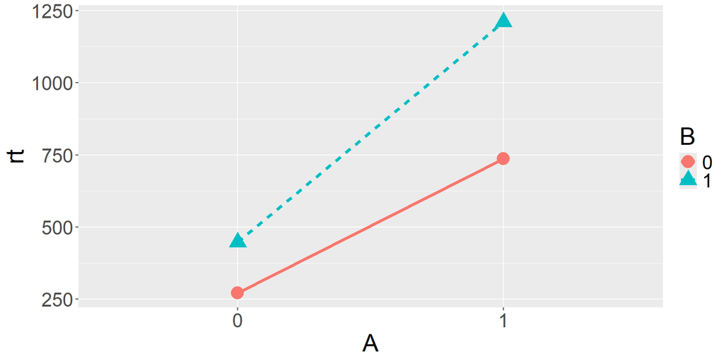

```r
eff = data.frame(allEffects(fitGLog)$"A:B")
ggplot(eff,aes(x=A,y=fit,group=B,color=B,shape=B,linetype=B))+
  geom_point(size=6)+
  geom_line(linewidth=1.5)+
  geom_errorbar(aes(ymin=lower,ymax=upper),width=0)+
  theme(text=element_text(size=24))+
  ylab("rt")
```

## reproduced data, `Gamma(link="log")`

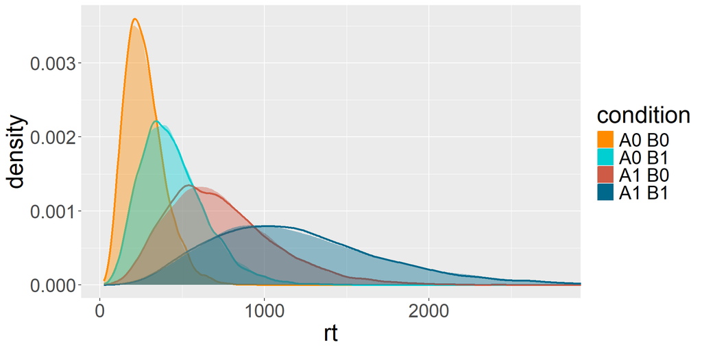

```r
df$sim = simulate(fitGLog)$sim_1
ggplot(df)+
  geom_density(aes(x=rt,group=condition,color=condition),linewidth=1)+
  geom_density(aes(x=sim,group=condition,fill=condition),color=NA,alpha=.4)+
  scale_color_manual(values=c("darkorange","darkturquoise","coral3","deepskyblue4"))+
  scale_fill_manual(values=c("darkorange","darkturquoise","coral3","deepskyblue4"))+
  theme(text=element_text(size=24))+
  coord_cartesian(xlim=c(min(df$rt),quantile(df$rt,.9975)))
```

## the model, `Gamma(link="identity")`

```r
fitGId = glm(rt ~ A * B, family=Gamma(link="identity"), data=df)
summary(fitGId)
```

```
Call:
glm(formula = rt ~ A * B, family = Gamma(link = "identity"),
    data = df)

Coefficients:
            Estimate Std. Error t value Pr(>|t|)
(Intercept)  270.996      1.081  250.73   <2e-16 ***
A1           465.937      3.139  148.44   <2e-16 ***
B1           176.170      2.097   84.02   <2e-16 ***
A1:B1        297.360      6.077   48.93   <2e-16 ***
---
Signif. codes:  0 '***' 0.001 '**' 0.01 '*' 0.05 '.' 0.1 ' ' 1

(Dispersion parameter for Gamma family taken to be 0.2009792)

    Null deviance: 25370  on 49999  degrees of freedom
Residual deviance: 10331  on 49996  degrees of freedom
AIC: 689236

Number of Fisher Scoring iterations: 3
```

## predicted effects, `Gamma(link="identity")`

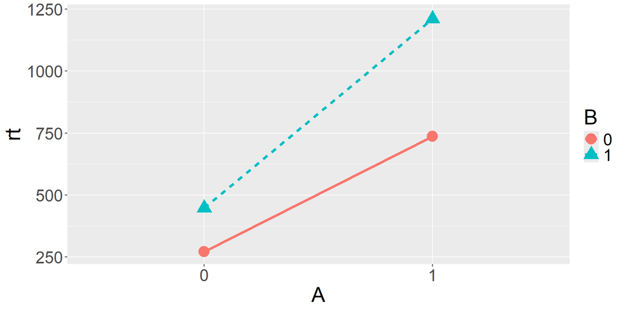

```r
eff = data.frame(allEffects(fitGId)$"A:B")
ggplot(eff,aes(x=A,y=fit,group=B,color=B,shape=B,linetype=B))+
  geom_point(size=6)+
  geom_line(linewidth=1.5)+
  geom_errorbar(aes(ymin=lower,ymax=upper),width=0)+
  theme(text=element_text(size=24))+
  ylab("rt")
```

## reproduced data, `Gamma(link="identity")`

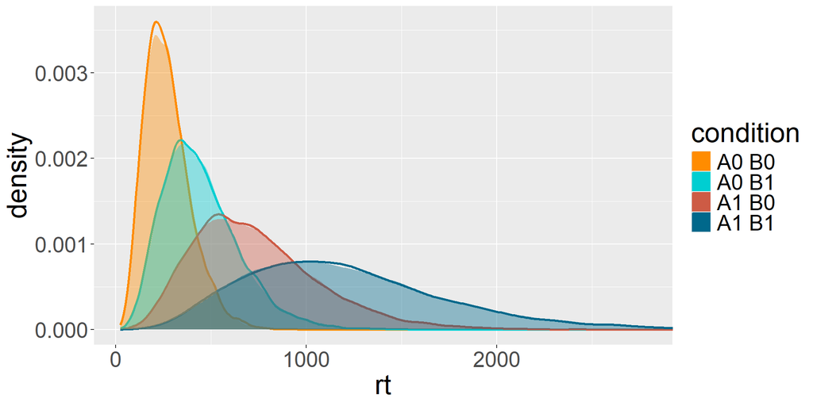

```r
df$sim = simulate(fitGId)$sim_1
ggplot(df)+
  geom_density(aes(x=rt,group=condition,color=condition),linewidth=1)+
  geom_density(aes(x=sim,group=condition,fill=condition),color=NA,alpha=.4)+
  scale_color_manual(values=c("darkorange","darkturquoise","coral3","deepskyblue4"))+
  scale_fill_manual(values=c("darkorange","darkturquoise","coral3","deepskyblue4"))+
  theme(text=element_text(size=24))+
  coord_cartesian(xlim=c(min(df$rt),quantile(df$rt,.9975)))
```

## `BIC` doesn’t tell you

Model with `Gamma(link="log")`

```r
BIC(fitGLog) # ok, but could be further improved removing interaction
```

```
[1] 689279.7
```

Model with `Gamma(link="identity")`

```r
BIC(fitGId) # ok, but you must keep a non-existent interaction term
```

```
[1] 689279.7
```

## comments, `Gamma(link="identity")`

- … so, **setting the wrong link function leads to discovering a false interaction** (because different differences on the response are taken as reflecting different differences on the linear predictor $X$, needing an interaction term to accomodate them)
- however, using the **correct distribution** (`Gamma`) leads to **perfectly fitting the data** anyways!
- problem is: yes, you fit the data, but **you need an interaction term that was NOT in the data-generating process**

## comments, `Gamma(link="identity")`

IMPORTANT!

1. **random effects** are there (and they are fitted)
2. some predictors are **continuous** instead of categorical

*but even in these cases… how many observations do we need to confidently tell the link function? Worst scenario is if N that leads to discovering false interaction is lower than N needed to tell the correct link function. Not tested this yet.*

## the model, `gaussian(link="log")`

```r
fitNLog = glm(rt ~ A * B, family=gaussian(link="log"), data=df)
summary(fitNLog)
```

```
Call:
glm(formula = rt ~ A * B, family = gaussian(link = "log"), data = df)

Coefficients:
             Estimate Std. Error t value Pr(>|t|)
(Intercept)  5.602104   0.011043 507.314   <2e-16 ***
A1           1.000393   0.011769  84.999   <2e-16 ***
B1           0.500826   0.012938  38.709   <2e-16 ***
A1:B1       -0.004565   0.013792  -0.331    0.741
---
Signif. codes:  0 '***' 0.001 '**' 0.01 '*' 0.05 '.' 0.1 ' ' 1

(Dispersion parameter for gaussian family taken to be 113148.9)

    Null deviance: 1.1948e+10  on 49999  degrees of freedom
Residual deviance: 5.6570e+09  on 49996  degrees of freedom
AIC: 723723

Number of Fisher Scoring iterations: 5
```

## predicted effects, `gaussian(link="log")`

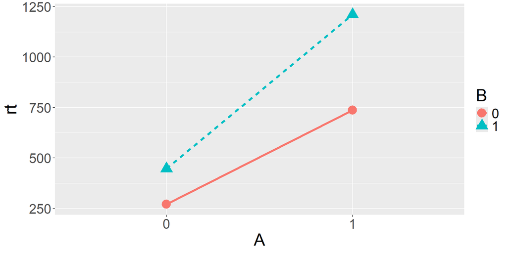

```r
eff = data.frame(allEffects(fitNLog)$"A:B")
ggplot(eff,aes(x=A,y=fit,group=B,color=B,shape=B,linetype=B))+
  geom_point(size=6)+
  geom_line(linewidth=1.5)+
  geom_errorbar(aes(ymin=lower,ymax=upper),width=0)+
  theme(text=element_text(size=24))+
  ylab("rt")
```

## reproduced data, `gaussian(link="log")`

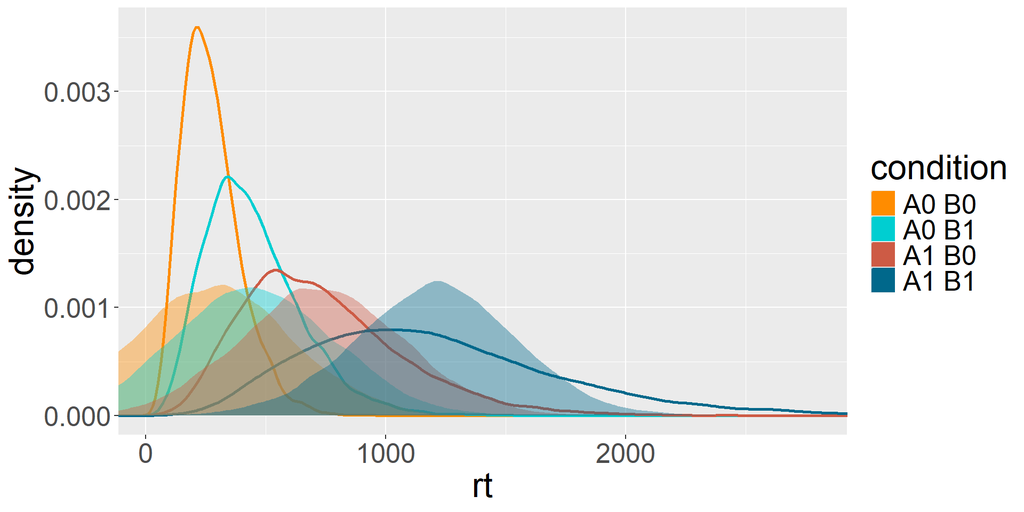

```r
df$sim = simulate(fitNLog)$sim_1
ggplot(df)+
  geom_density(aes(x=rt,group=condition,color=condition),linewidth=1)+
  geom_density(aes(x=sim,group=condition,fill=condition),color=NA,alpha=.4)+
  scale_color_manual(values=c("darkorange","darkturquoise","coral3","deepskyblue4"))+
  scale_fill_manual(values=c("darkorange","darkturquoise","coral3","deepskyblue4"))+
  theme(text=element_text(size=24))+
  coord_cartesian(xlim=c(min(df$rt),quantile(df$rt,.9975)))
```

## comments, `gaussian(link="log")`

- … so, **setting the correct link function avoids discovering false interactions** *even if the distribution is wrong*
- however, using the **wrong distribution** (`gaussian`) leads to poorly fitting the observed data!
- problems are 1) **poor fit with the data**; 2) residuals will be **skewed and heteroscedastic**
- `BIC` cannot be compared across families

## Paradox - Interaction or not?

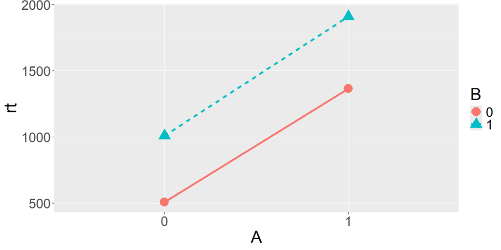

```r
set.seed(11)
N = 2e4
b0 = 0
b1 = 1.00
b2 = 0.70
b1b2 = -0.347
A = rbinom(N,1,.5)
B = rbinom(N,1,.5)
X = b0 + b1*A + b2*B + b1b2*A*B
rt = rgamma(N,shape=5,scale=100*exp(X))
df = data.frame(rt,A,B)
df$A = as.factor(df$A)
df$B = as.factor(df$B)

fitGLog = glm(rt ~ A * B, family=Gamma(link="log"), data=df)
eff = data.frame(allEffects(fitGLog)$"A:B")

ggplot(eff,aes(x=A,y=fit,group=B,color=B,shape=B,linetype=B))+
  geom_point(size=6)+
  geom_line(linewidth=1.5)+
  geom_errorbar(aes(ymin=lower,ymax=upper),width=0)+
  theme(text=element_text(size=24))+
  ylab("rt")
```

### `Gamma(link="identity")` → *positive* interaction

```r
fitGId = glm(rt ~ A * B, family=Gamma(link="identity"), data=df)
summary(fitGId)
```

```
Call:
glm(formula = rt ~ A * B, family = Gamma(link = "identity"),
    data = df)

Coefficients:
            Estimate Std. Error t value Pr(>|t|)
(Intercept)  509.253      3.246 156.910  < 2e-16 ***
A1           856.896      9.228  92.856  < 2e-16 ***
B1           500.933      7.172  69.842  < 2e-16 ***
A1:B1         45.467     16.496   2.756  0.00585 **
---
Signif. codes:  0 '***' 0.001 '**' 0.01 '*' 0.05 '.' 0.1 ' ' 1

(Dispersion parameter for Gamma family taken to be 0.2007665)

    Null deviance: 8448.1  on 19999  degrees of freedom
Residual deviance: 4152.8  on 19996  degrees of freedom
AIC: 301261

Number of Fisher Scoring iterations: 3
```

### `Gamma(link="log")` → *negative* interaction

```r
fitGLog = glm(rt ~ A * B, family=Gamma(link="log"), data=df)
summary(fitGLog)
```

```
Call:
glm(formula = rt ~ A * B, family = Gamma(link = "log"), data = df)

Coefficients:
             Estimate Std. Error t value Pr(>|t|)
(Intercept)  6.232945   0.006373  978.01   <2e-16 ***
A1           0.986806   0.008978  109.92   <2e-16 ***
B1           0.684945   0.008984   76.24   <2e-16 ***
A1:B1       -0.348504   0.012674  -27.50   <2e-16 ***
---
Signif. codes:  0 '***' 0.001 '**' 0.01 '*' 0.05 '.' 0.1 ' ' 1

(Dispersion parameter for Gamma family taken to be 0.2007665)

    Null deviance: 8448.1  on 19999  degrees of freedom
Residual deviance: 4152.8  on 19996  degrees of freedom
AIC: 301261

Number of Fisher Scoring iterations: 4
```